# 동의보감 의학입문 경악전서 비교 summary

## 0. 데이터 준비

관찰빈도 (YH:의학입문, DY:동의보감, GA:경악전서)

```
##            肝   心   脾   肺   腎   精    氣   神   血   痰  鬱   陰   陽
## 의학입문 1100 3418 1563 1298 1496  847  7928 1186 4726 1827 576 3451 3280
## 동의보감 1164 3835 1322 1299 1523 1111  7649 1991 4220 1723 527 3386 3001
## 경악전서 1359 2489 2565 1185 1587 1181 12045 1512 5105 1662 549 5246 4883
##            表  裏   寒   熱   虛   實   風  暑   濕  燥   火
## 의학입문  774 867 3850 6371 3277 1233 4107 352 1671 701 2485
## 동의보감  352 407 3373 5279 2749 1404 3805 313 1265 519 2058
## 경악전서 1117 924 6241 8021 5654 2332 3159 352 1448 598 3257
```

상대빈도1 (1천자 당 출현 빈도) -> 빈도 자체 비교 편리

```
##            肝   心   脾   肺   腎   精    氣   神   血   痰   鬱   陰   陽
## 의학입문 1.58 4.91 2.25 1.86 2.15 1.22 11.39 1.70 6.79 2.62 0.83 4.96 4.71
## 동의보감 1.34 4.42 1.52 1.50 1.75 1.28  8.81 2.29 4.86 1.98 0.61 3.90 3.46
## 경악전서 1.58 2.89 2.97 1.37 1.84 1.37 13.97 1.75 5.92 1.93 0.64 6.08 5.66
##            表   裏   寒   熱   虛   實   風   暑   濕   燥   火
## 의학입문 1.11 1.25 5.53 9.15 4.71 1.77 5.90 0.51 2.40 1.01 3.57
## 동의보감 0.41 0.47 3.88 6.08 3.17 1.62 4.38 0.36 1.46 0.60 2.37
## 경악전서 1.30 1.07 7.24 9.30 6.56 2.70 3.66 0.41 1.68 0.69 3.78
```

상대빈도2 : 문서들 평균 길이 -> 카이제곱

```
##               肝      心      脾      肺      腎      精       氣      神
## 의학입문 1278.31 3972.07 1816.37 1508.41 1738.51  984.30  9213.16 1378.26
## 동의보감 1084.37 3572.64 1231.56 1210.13 1418.81 1034.99  7125.72 1854.79
## 경악전서 1274.79 2334.77 2406.06 1111.57 1488.66 1107.82 11298.65 1418.31
##               血      痰     鬱      陰      陽      表      裏      寒
## 의학입문 5492.11 2123.16 669.37 4010.42 3811.70  899.47 1007.54 4474.10
## 동의보감 3931.30 1605.13 490.95 3154.36 2795.70  327.92  379.16 3142.25
## 경악전서 4788.68 1559.02 514.98 4920.94 4580.43 1047.79  866.75 5854.29
##               熱      虛      實      風     暑      濕     燥      火
## 의학입문 7403.77 3808.22 1432.87 4772.76 409.06 1941.88 814.64 2887.83
## 동의보감 4917.85 2560.94 1307.95 3544.69 291.59 1178.46 483.49 1917.21
## 경악전서 7523.99 5303.66 2187.50 2963.26 330.19 1358.28 560.95 3055.19
```

## 단순 빈도 비교

### Overview

#### Scatter plot

기대빈도와 관찰빈도 사이의 관계를 살펴보자. 이를 위해 Pearson’s Chi-squared test를 사용했다.

※ 상대빈도2를 사용했다. chi-squared 값은 데이터 크기에 따라 변한다. 상대빈도1을 사용하면 너무 작은 값 때문에 결과가 잘 나오지 않는다. 또 관찰빈도를 그대로 사용하면 텍스트 크기가 다르기 때문에 문제가 된다. 따라서 실제 관찰빈도와 유사한 값으로서 서적 사이에 텍스트 크기를 상쇄한 상대빈도2를 썼다.)

먼저 의학입문과 비교한 동의보감의 핵심어 분포이다.

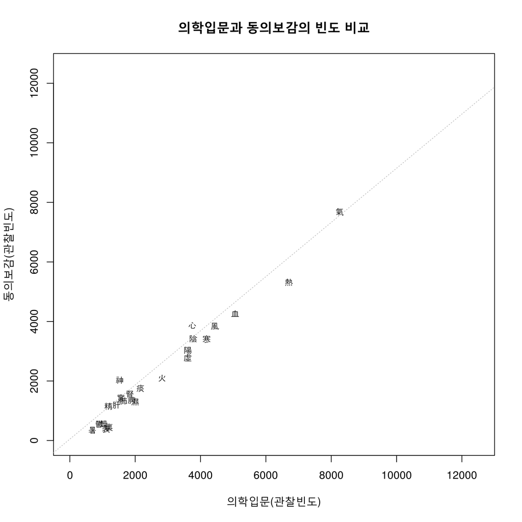

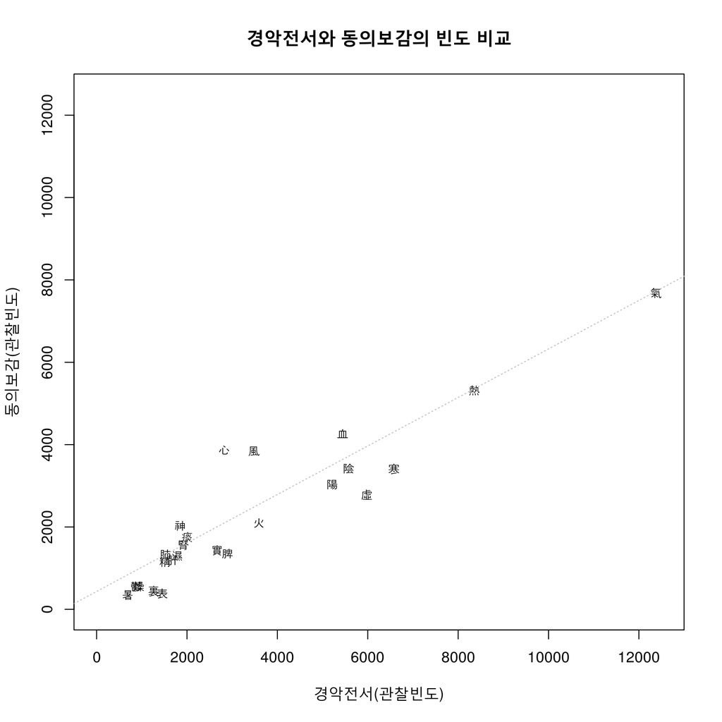

의학입문과 동의보감의 상관계수(Correlation coefficient)는 0.98, 경악전서와 동의보감의 상관계수는 0.93로 나타났다.

#### standardized residual

```
##    동의보감obs 의학입문obs 동의보감exp 의학입문exp 동의보감res 의학입문res
## 肝     1084.37     1278.31     1008.88     1353.80       75.49      -75.49
## 心     3572.64     3972.07     3221.64     4323.07      351.00     -351.00
## 脾     1231.56     1816.37     1301.49     1746.44      -69.93       69.93
## 肺     1210.13     1508.41     1160.84     1557.71       49.30      -49.30
## 腎     1418.81     1738.51     1348.19     1809.12       70.61      -70.61
## 精     1034.99      984.30      862.25     1157.04      172.74     -172.74
## 氣     7125.72     9213.16     6976.81     9362.07      148.91     -148.91
## 神     1854.79     1378.26     1380.53     1852.52      474.26     -474.26
## 血     3931.30     5492.11     4023.86     5399.55      -92.55       92.55
## 痰     1605.13     2123.16     1592.00     2136.29       13.12      -13.12
## 鬱      490.95      669.37      495.46      664.86       -4.52        4.52
## 陰     3154.36     4010.42     3059.41     4105.37       94.95      -94.95
## 陽     2795.70     3811.70     2821.40     3786.00      -25.71       25.71
## 表      327.92      899.47      524.10      703.29     -196.18      196.18
## 裏      379.16     1007.54      592.13      794.57     -212.97      212.97
## 寒     3142.25     4474.10     3252.23     4364.12     -109.98      109.98
## 熱     4917.85     7403.77     5261.41     7060.21     -343.56      343.56
## 虛     2560.94     3808.22     2719.67     3649.48     -158.73      158.73
## 實     1307.95     1432.87     1170.35     1570.47      137.60     -137.60
## 風     3544.69     4772.76     3551.61     4765.85       -6.91        6.91
## 暑      291.59      409.06      299.18      401.47       -7.59        7.59
## 濕     1178.46     1941.88     1332.40     1787.93     -153.94      153.94
## 燥      483.49      814.64      554.31      743.82      -70.82       70.82
## 火     1917.21     2887.83     2051.78     2753.26     -134.57      134.57
##    동의보감sr 의학입문sr
## 肝       2.38      -2.05
## 心       6.18      -5.34
## 脾      -1.94       1.67
## 肺       1.45      -1.25
## 腎       1.92      -1.66
## 精       5.88      -5.08
## 氣       1.78      -1.54
## 神      12.76     -11.02
## 血      -1.46       1.26
## 痰       0.33      -0.28
## 鬱      -0.20       0.18
## 陰       1.72      -1.48
## 陽      -0.48       0.42
## 表      -8.57       7.40
## 裏      -8.75       7.56
## 寒      -1.93       1.66
## 熱      -4.74       4.09
## 虛      -3.04       2.63
## 實       4.02      -3.47
## 風      -0.12       0.10
## 暑      -0.44       0.38
## 濕      -4.22       3.64
## 燥      -3.01       2.60
## 火      -2.97       2.56
```

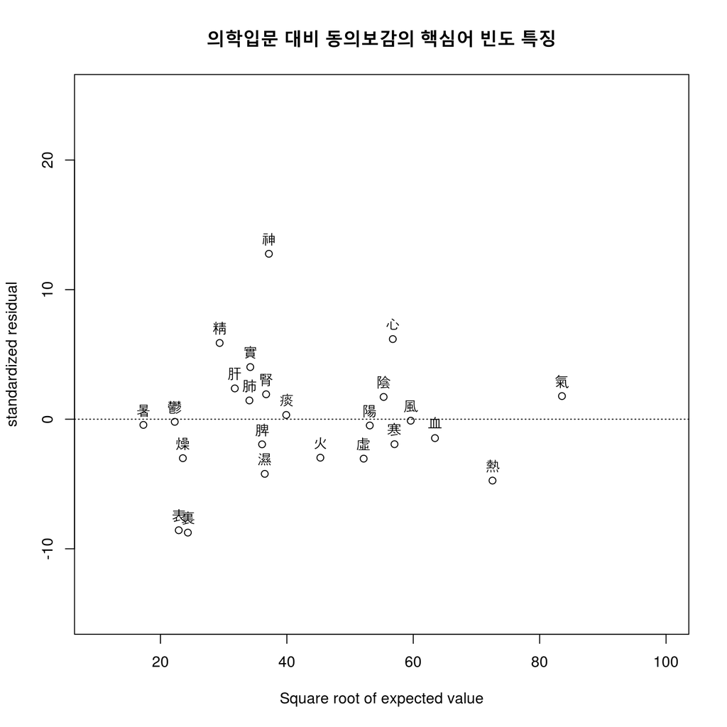

다음으로 경악전서와 비교한 동의보감의 핵심어 분포이다.

```
##    동의보감obs 경악전서obs 동의보감exp 경악전서exp 동의보감res 경악전서res
## 肝   1084.3685   1274.7919    990.5767   1368.5837    93.79183   -93.79183
## 心   3572.6403   2334.7734   2480.4359   3426.9778  1092.20435 -1092.20435
## 脾   1231.5594   2406.0642   1527.3845   2110.2391  -295.82510   295.82510
## 肺   1210.1329   1111.5735    974.8503   1346.8561   235.28261  -235.28261
## 腎   1418.8086   1488.6643   1220.8050   1686.6679   198.00362  -198.00362
## 精   1034.9944   1107.8214    899.7367   1243.0790   135.25762  -135.25762
## 氣   7125.7172  11298.6524   7736.1212  10688.2484  -610.40398   610.40398
## 神   1854.7919   1418.3115   1374.3279   1898.7755   480.46400  -480.46400
## 血   3931.3017   4788.6775   3661.3907   5058.5885   269.91098  -269.91098
## 痰   1605.1263   1559.0170   1328.5771   1835.5662   276.54913  -276.54913
## 鬱    490.9469    514.9822    422.3748    583.5543    68.57213   -68.57213
## 陰   3154.3572   4920.9407   3390.6985   4684.5994  -236.34131   236.34131
## 陽   2795.6958   4580.4333   3097.1279   4279.0013  -301.43208   301.43208
## 表    327.9190   1047.7870    577.6387    798.0673  -249.71968   249.71968
## 裏    379.1563    866.7459    523.1360    722.7663  -143.97965   143.97965
## 寒   3142.2466   5854.2872   3777.5119   5219.0219  -635.26533   635.26533
## 熱   4917.8535   7523.9926   5224.1477   7217.6983  -306.29428   306.29428
## 虛   2560.9356   5303.6597   3302.2276   4562.3677  -741.29200   741.29200
## 實   1307.9497   2187.5016   1467.6885   2027.7628  -159.73881   159.73881
## 風   3544.6926   2963.2580   2732.5925   3775.3581   812.10009  -812.10009
## 暑    291.5871    330.1889    261.0746    360.7014    30.51249   -30.51249
## 濕   1178.4589   1358.2772   1065.1381   1471.5980   113.32083  -113.32083
## 燥    483.4942    560.9460    438.5450    605.8951    44.94918   -44.94918
## 火   1917.2083   3055.1856   2087.8349   2884.5590  -170.62663   170.62663
##    동의보감sr 경악전서sr
## 肝   2.980032  -2.535300
## 心  21.930064 -18.657277
## 脾  -7.569389   6.439753
## 肺   7.535652  -6.411051
## 腎   5.666958  -4.821235
## 精   4.509247  -3.836298
## 氣  -6.939940   5.904241
## 神  12.960319 -11.026154
## 血   4.460643  -3.794948
## 痰   7.587154  -6.454867
## 鬱   3.336558  -2.838618
## 陰  -4.058776   3.453054
## 陽  -5.416390   4.608061
## 表 -10.390217   8.839608
## 裏  -6.294972   5.355527
## 寒 -10.335994   8.793476
## 熱  -4.237709   3.605284
## 虛 -12.899884  10.974738
## 實  -4.169592   3.547332
## 風  15.535389 -13.216927
## 暑   1.888406  -1.606585
## 濕   3.472216  -2.954032
## 燥   2.146420  -1.826094
## 火  -3.734210   3.176926
```

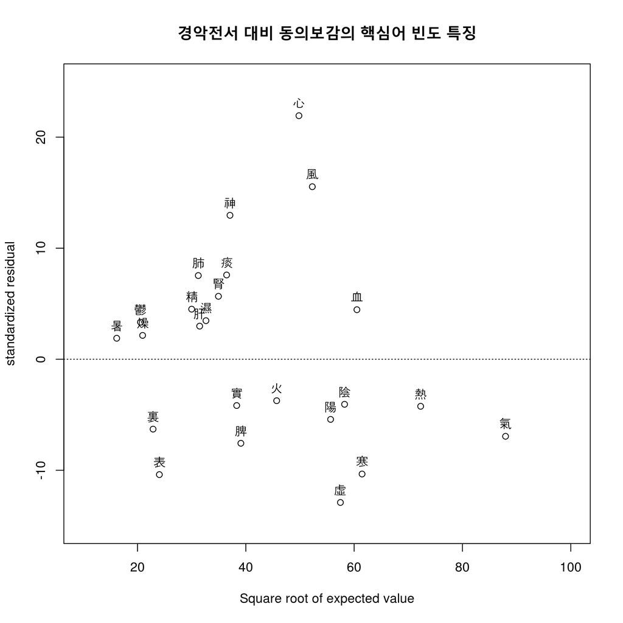

### 주제별 비교

전체 핵심어 상대빈도

```
##                肝        心       脾       肺       腎       精        氣
## 의학입문 1.580115  4.909847 2.245199 1.864535 2.148956 1.216688 11.388317
## 동의보감 1.340379  4.416112 1.522321 1.495835 1.753778 1.279348  8.808041
## 경악전서 1.575760  2.885995 2.974116 1.374007 1.840126 1.369369 13.966173
## Sum      4.496254 12.211954 6.741636 4.734378 5.742860 3.865405 34.162532
##                神        血       痰        鬱        陰        陽
## 의학입문 1.703651  6.788747 2.624427 0.8274055  4.957251  4.711615
## 동의보감 2.292693  4.859450 1.984084 0.6068555  3.899075  3.455737
## 경악전서 1.753163  5.919245 1.927088 0.6365653  6.082735  5.661837
## Sum      5.749508 17.567443 6.535599 2.0708263 14.939061 13.829188
##                表        裏        寒        熱        虛       實
## 의학입문 1.111826 1.2454177  5.530401  9.151737  4.707305 1.771165
## 동의보감 0.405338 0.4686721  3.884106  6.078919  3.165552 1.616746
## 경악전서 1.295161 1.0713776  7.236437  9.300346  6.555811 2.703953
## Sum      2.812325 2.7854674 16.650944 24.531002 14.428668 6.091864
##                 風        暑       濕        燥       火       Sum
## 의학입문  5.899574 0.5056367 2.400338 1.0069640 3.569623  83.86674
## 동의보감  4.381566 0.3604284 1.456684 0.5976433 2.369846  62.49921
## 경악전서  3.662859 0.4081439 1.678955 0.6933808 3.776490  86.34910
## Sum      13.943999 1.2742090 5.535977 2.2979880 9.715959 232.71505
```

전체 글자수 대비 핵심어 빈도 합계 퍼센테이지

```
## 의학입문 동의보감 경악전서
##     8.39     6.25     8.63
```

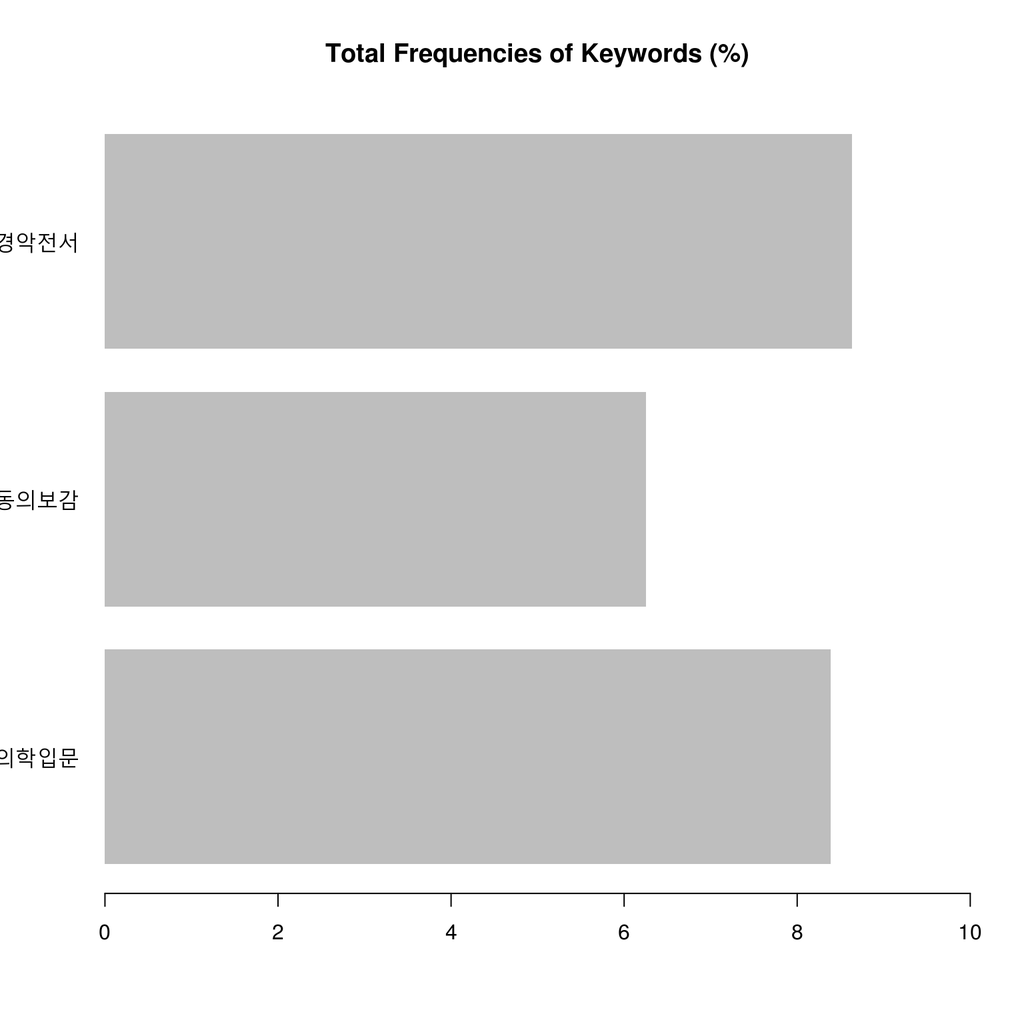

전체 분포

노란색 : 동의보감, 빨간색 : 의학입문, 초록색 : 경악전서

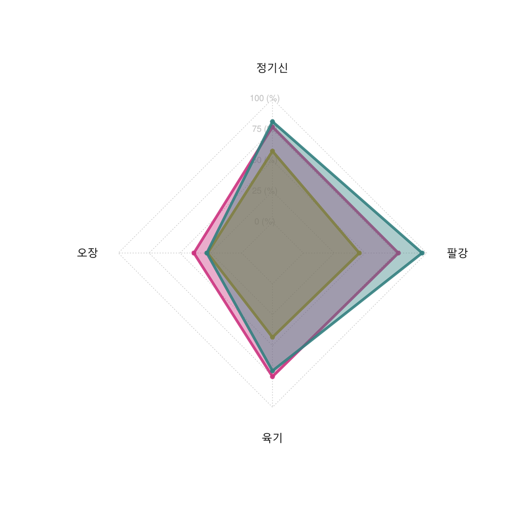

오장

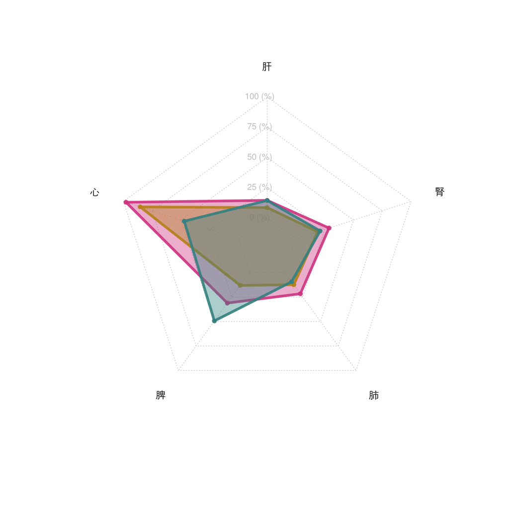

육기

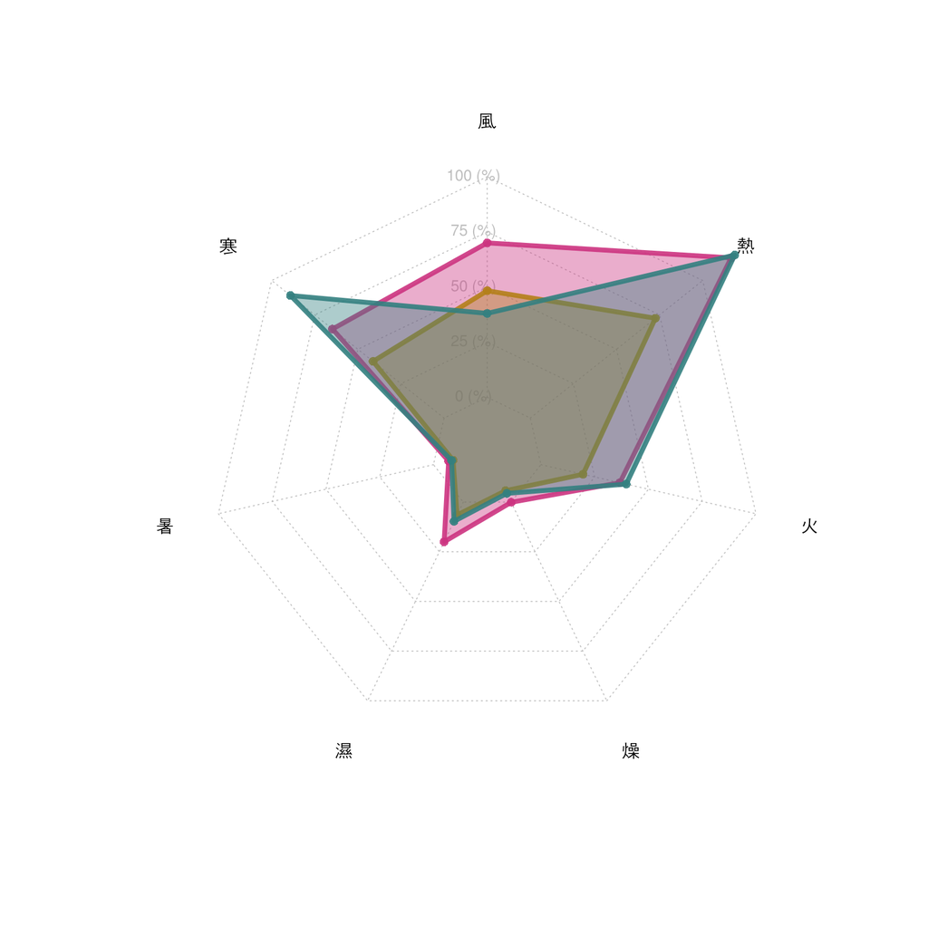

정신기혈담울

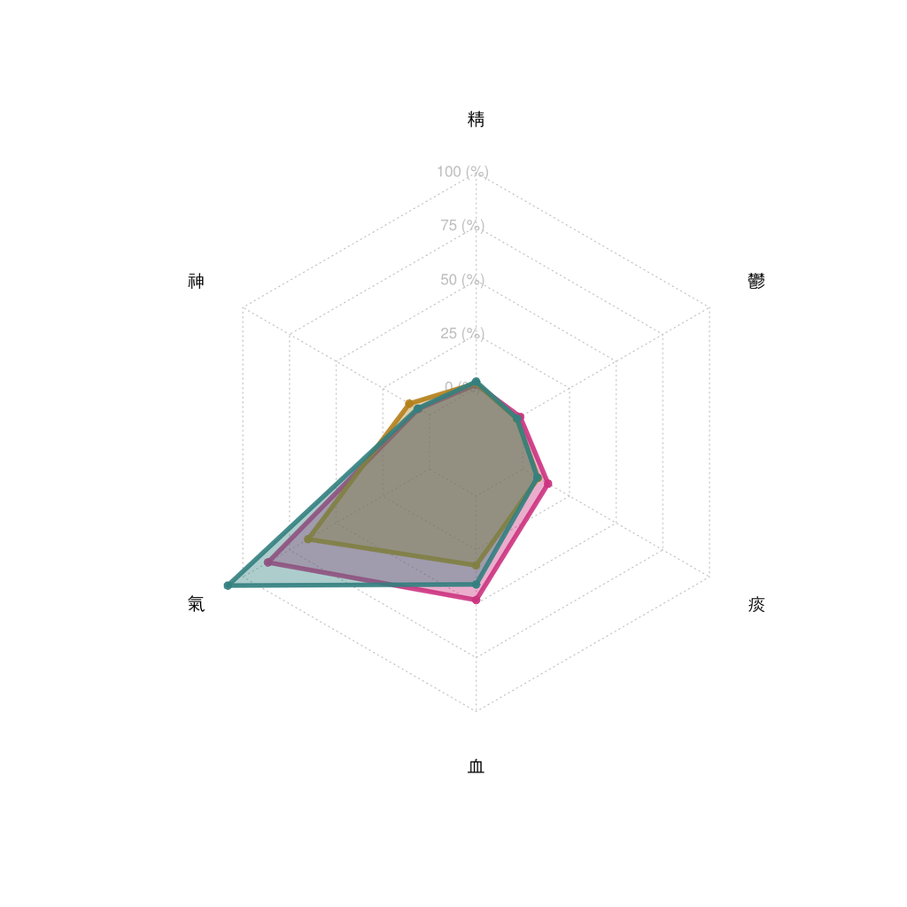

팔강

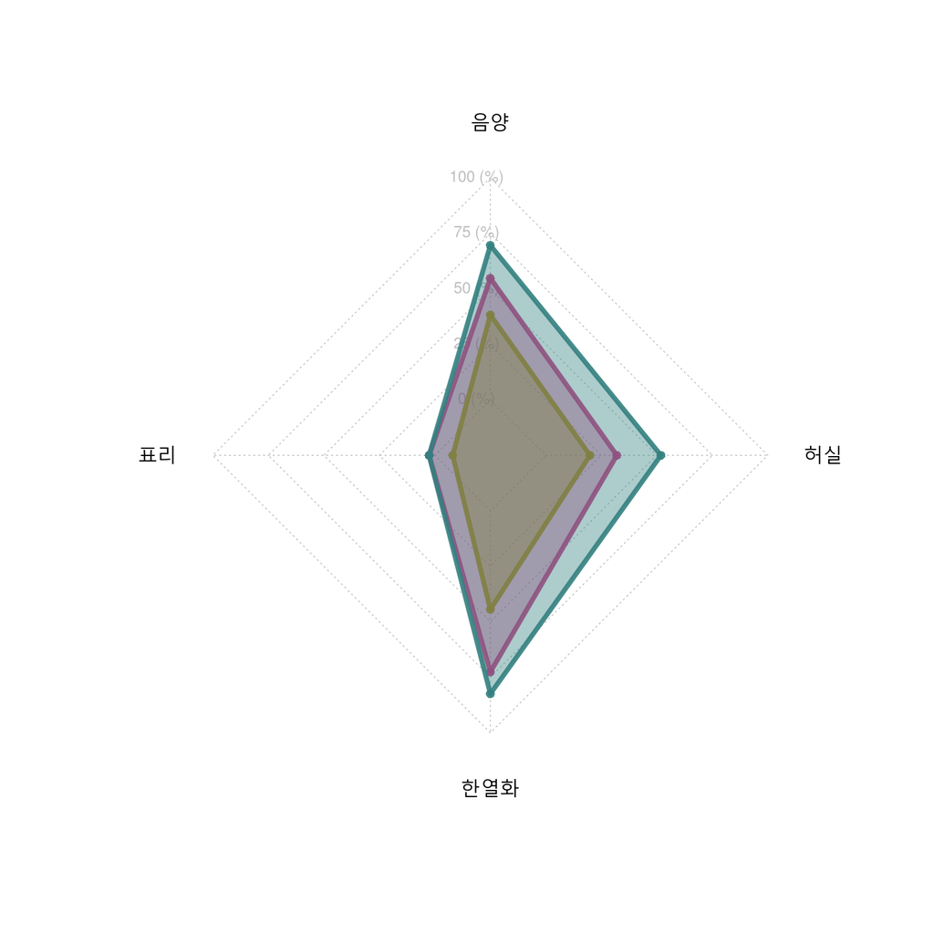

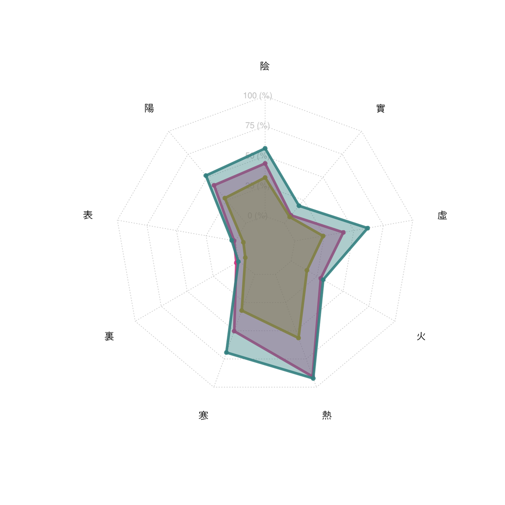

## 의서 상호 비교

### homogeneity

각 의서들을 100조각으로 나누어 임의로 재배열 하여 2개의 sub text를 만든 뒤, 이 둘 사이의 CBDF(chi-squared 값을 자유도로 나눈 것)를 구한다. 이것을 반복하여 값을 만든다.

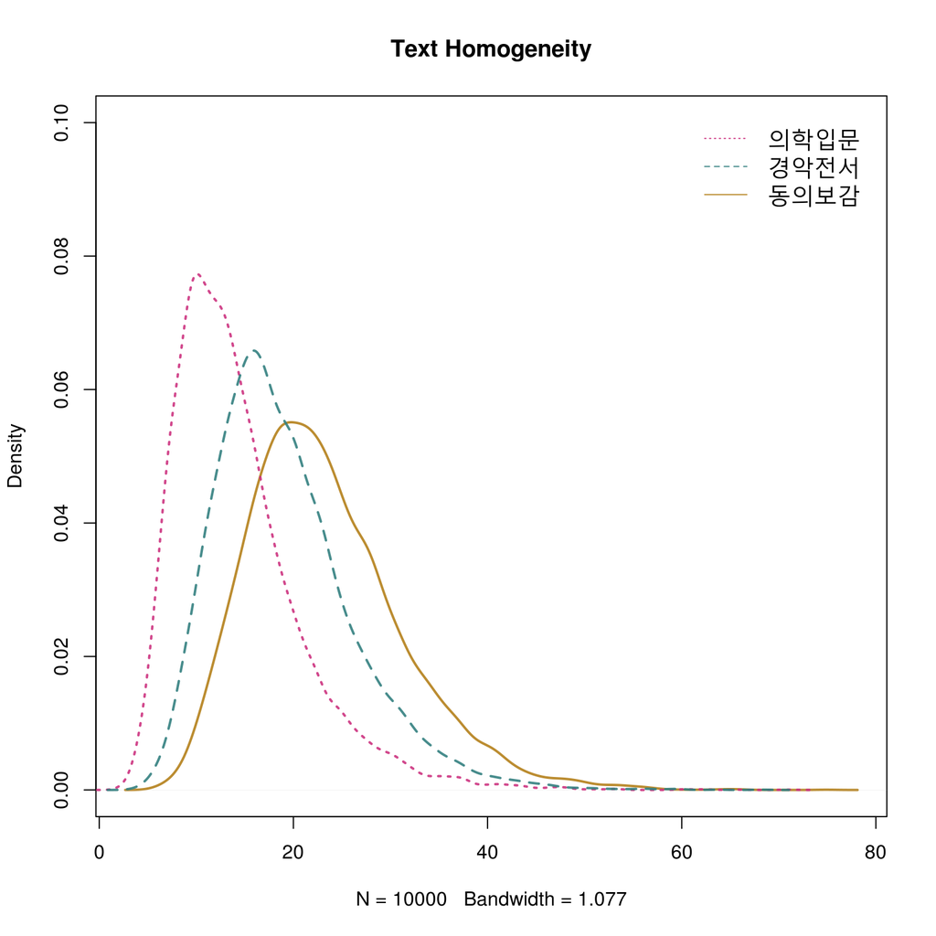

평균과 표준편차

```
##    YH    DY    GA
## 14.23 23.28 19.03
```

```
##   YH   DY   GA
## 6.66 7.95 7.16
```

### 의학 사상 유사성 비교

의서들 간에 CBDF 값을 구하여 MDS으로 시각화 한다.

```
##          YH.rlfrq DY.rlfrq
## DY.rlfrq    37.72
## GA.rlfrq    99.66   130.30
```

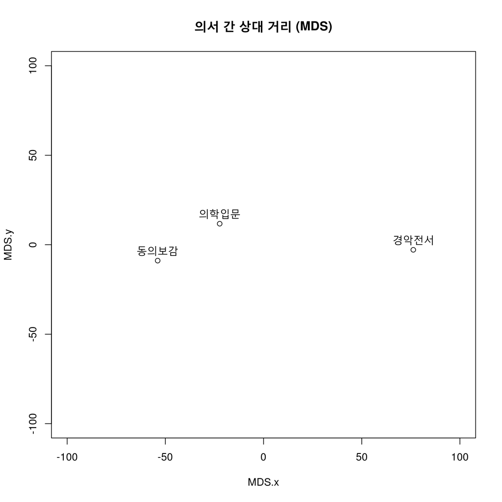